# Election Summary

This is a report summarizing presidential election by county in Washington state. The data is extracted from **United States General Election Presidential Results by County from 2008 to 2016**.

## Summary

The United States General Election Presidential Results by County from 2008-2016 set contains data from 3112 different counties, including 39 counties from Washington state. The data set shows that in 2008, 131,183,095 people voted in the presidential election.

## Democratic counties vs. Republican counties in 2008 and in 2016

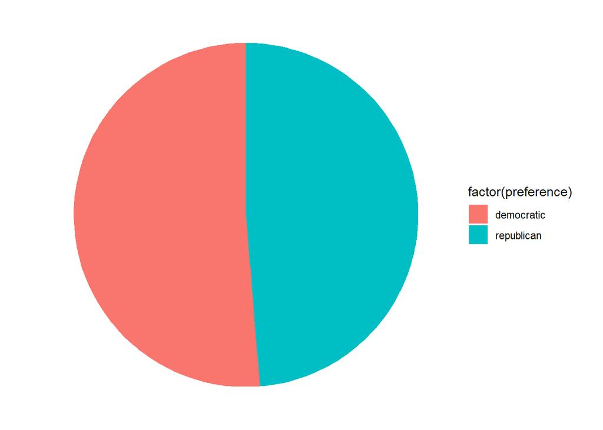

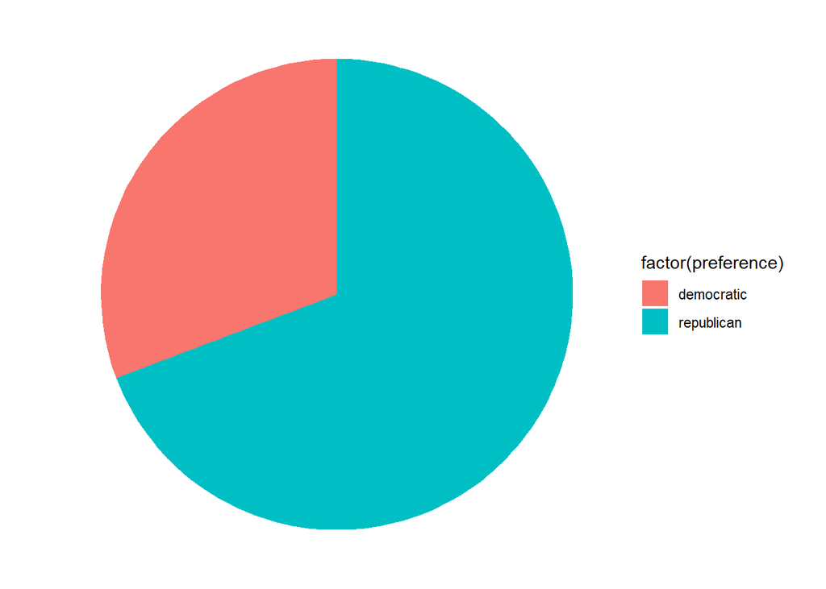

## General Map of US and specific data of total number of vote in 2008 for each state

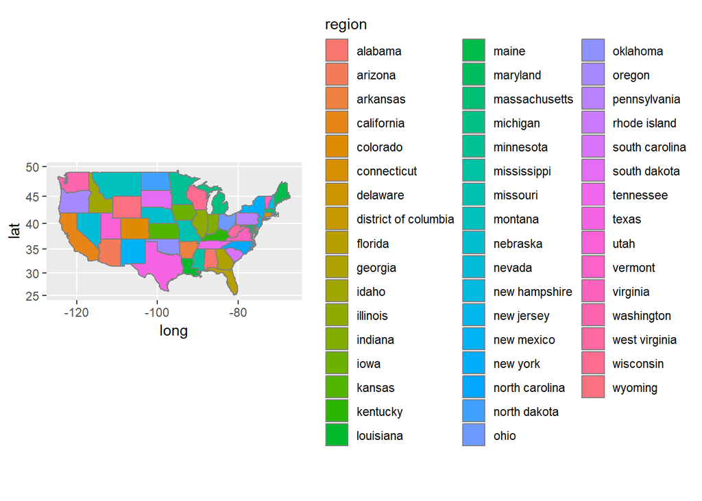

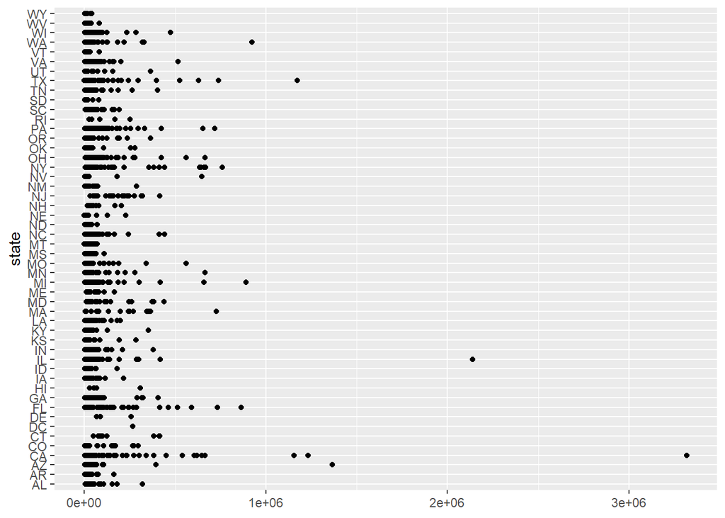

#### The first graph showing the big map of the United States, so people could have a general idea about U.S. For the second graph, it shows the total number in 2008 for each state (by ploting each point).Since each state has many counties, it is easy to see the difference between each state. For example, there is a big difference in CA.

Based on data, we compared the number of people who voted for the Democratic candidate and the people who voted for the Republican candidate in each county to see which county was more Democratic or Republican overall. The first pie chart shows the percentage of Democratic counties vs. Republican counties in 2008 in Washington state. The second pie chart shows that of 2016. In 2008, less than half of the counties were Republican. However, in 2016, the number of Republican counties increased to where almost 70% of the counties were Republican.